# The Influence of Media on Tesla’s Stock Price

Official Answers

2018-11-12

#Introduction

We hypothesize that news from major media outlets such as Twitter and Wall Street Journal may have a strong influence (such as correlation) on the stock price of Tesla, Inc. One might imagine that stock prices are particularly susceptible to breaking news on social media since the news reflect new market information. For instance, when Elon Musk (Tesla’s CEO) himself gives out the unplanned news, it seems like the market would experience extreme momentary fluctuations.

The purpose of the project is to analyze and (explore correlation) between social media and news platforms with stock price. We believe that if our research finds a correlation between stock movements and news, then we might be able to create trading strategies. Otherwise, the absence of correlation should teach us not to trade stocks purely based on breaking news.

The tool we majorly use is R language by Rstudio. We might also utilize Python if needed for specific libraries.

#Exploratory Data Analysis

## Stock Data

We get the historical data for Tesla stock from Yahoo! Finance. We take the close and open price and volume of Teala stock from 2016-11-10 to 2018-11-10.

###daily price data

We import the daily price and plot the log of close price over time to see how Tesla’s stock price has changed over time. We also computed the basic summary statistics(mean,range,variance) of the stock price.

```r
library(tidyverse)
daily_price<-read.csv('Data/Stock_Data/TSLA.csv')%>%
  transmute(Date=as.character(Date),Open,Close,Volume)
problems(daily_price)
```

```
## # tibble [0 x 4]
## # ... with 4 variables: row <int>, col <int>, expected <chr>, actual <chr>
```

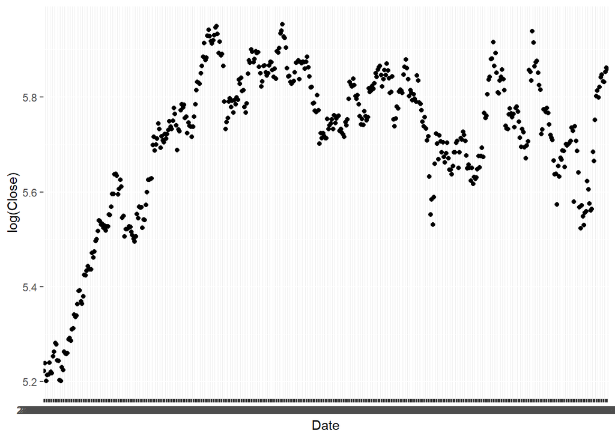

```r
daily_price%>%ggplot()+geom_point(aes(Date,log(Close)))
```

```r
as.tibble(list(mean=mean(daily_price$Close),min=min(daily_price$Close),
               max=max(daily_price$Close),variance=var(daily_price$Close)))
```

```
## # A tibble: 1 x 4
##    mean   min   max variance
##   <dbl> <dbl> <dbl>    <dbl>
## 1  306.  181.   385    2084.
```

As we can see from the graph, Tesla’s stock price exprienced a relatively steady growth at first but started to have more volatility during the past one year or so. This is the period in which we are mainly interested in.

###minutely data

Considering that we may need to look into the change in stock price in more detail to see how it responded to news on social media, we also obtained the minutely price and volume data for the past 7 months from Bloomberg and imported it.

```r
library(readxl)
minutely_price<- read_excel("Data/Stock_Data/bloomberg_tsla_minutely_price_04252018_11072018.xlsx",
                            sheet = "Sheet1")%>%transmute(Date=Dates,Open,Close,Volume)
problems(minutely_price)
```

```
## # tibble [0 x 4]
## # ... with 4 variables: row <int>, col <int>, expected <chr>, actual <chr>
```

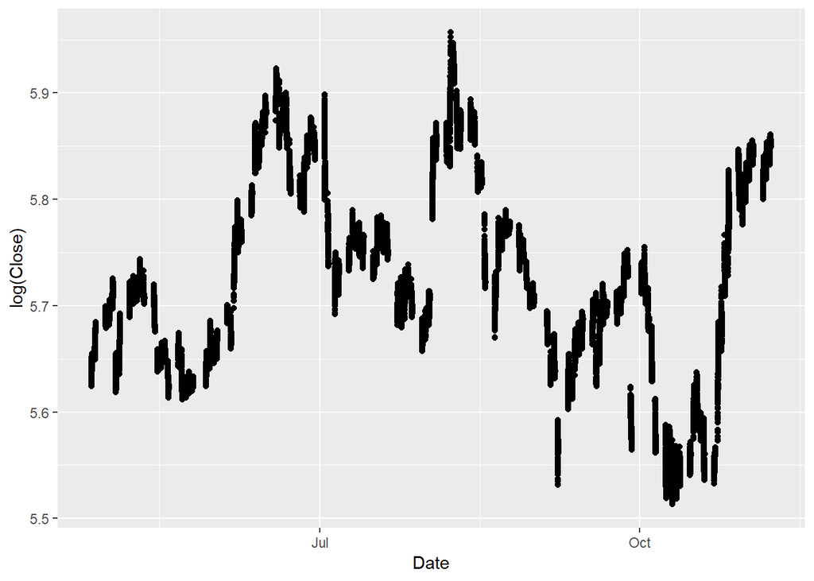

```r
minutely_price%>%ggplot()+geom_point(aes(Date,log(Close)),position="jitter")
```

```r
as.tibble(list(mean=mean(minutely_price$Close),min=min(minutely_price$Close),
               max=max(minutely_price$Close),variance=var(minutely_price$Close)))
```

```
## # A tibble: 1 x 4
##    mean   min   max variance
##   <dbl> <dbl> <dbl>    <dbl>
## 1  308.  248.  386.     806.
```

###comparing to S&P500

To see how Tesla’s stock change is related to the change in stock market, we compared it to the price of S&P 500.

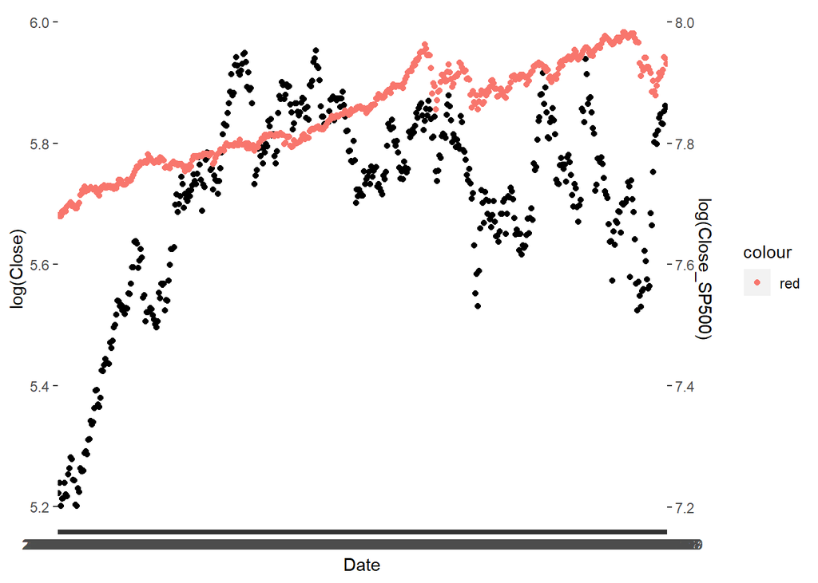

```r
SP500<-read.csv('data/^GSPC.CSV')%>%
  transmute(Date=as.character(Date),Open_SP500=Open,Close_SP500=Close,Volume_SP500=Volume)

daily_price%>%left_join(SP500,by="Date")%>%
  ggplot(aes(Date))+geom_point(aes(y=log(Close)))+
  geom_point(aes(y=log(Close_SP500)-2,color="red"))+
  scale_y_continuous(sec.axis = sec_axis(~.+2,name="log(Close_SP500)"))
```

As shown in the graph, the correlation between S&P500 and Tesla is not very strong. While S&P500 is generally growing over time, there is more ups and downs in the stock price of Tesla. So, there must be other reasons driven the change and we believe the news and releases on social media is one big reason for that.

##Twitter Data

```r
library(tidyr)
library(stringr)
library(dplyr)
library(gtable)
```

```r
elon_musk <- read_csv("data/Twitter_Data/Elon Musk (@elonmusk) _ Twitter.csv")
elon_musk <- elon_musk %>% distinct()

problems(elon_musk)
```

```
## # tibble [0 x 4]
## # ... with 4 variables: row <int>, col <int>, expected <chr>, actual <chr>
```

```r
(by_date <- elon_musk %>%  separate(time, into = c("year", "month", "day"), sep = "-" ) )
```

```
## # A tibble: 833 x 7
##    year  month day   text                           replies retweets likes
##    <chr> <chr> <chr> <chr>                            <int>    <int> <int>
##  1 2017  08    29    Napa Valley Tesla Finnish Tes~     165      677  4900
##  2 2017  09    28    Fly to most places on Earth i~    2700    15000 40000
##  3 2017  09    28    Part 2 https://www.instagram.~     443     2300  8400
##  4 2017  09    28    BFR is capable of transportin~     568     7400 21000
##  5 2017  10    02    GM just announced that it is ~     408     2100  7000
##  6 2017  10    03    Aiming for two rocket landing~    1100     3500 24000
##  7 2017  10    04    I believe I can flyhttps://m.~     784     2600 15000
##  8 2017  10    06    Great initial conversation wi~     705     4400 18000
##  9 2017  10    06    Tesla Semi unveil now Nov 16.~    2100     9700 54000
## 10 2017  10    08    "Jupiter is bighttps://twitte~     685     4500 29000
## # ... with 823 more rows
```

```r
(daily_res <- by_date %>% group_by(year, month, day) %>% summarise(
  dailyLikes = sum(likes),
  dailyReplies = sum(replies),
  dailyRetweets = sum(retweets)
  )  )
```

```
## # A tibble: 280 x 6
## # Groups:   year, month [?]
##    year  month day   dailyLikes dailyReplies dailyRetweets
##    <chr> <chr> <chr>      <int>        <int>         <int>
##  1 2017  08    29          4900          165           677
##  2 2017  09    28         69400         3711         24700
##  3 2017  10    02          7000          408          2100
##  4 2017  10    03         24000         1100          3500
##  5 2017  10    04         15000          784          2600
##  6 2017  10    06         72000         2805         14100
##  7 2017  10    08         37600         1185          5800
##  8 2017  10    09         60900         1953         11567
##  9 2017  10    11         35900         1385          5818
## 10 2017  10    14         14000          778          1900
## # ... with 270 more rows
```

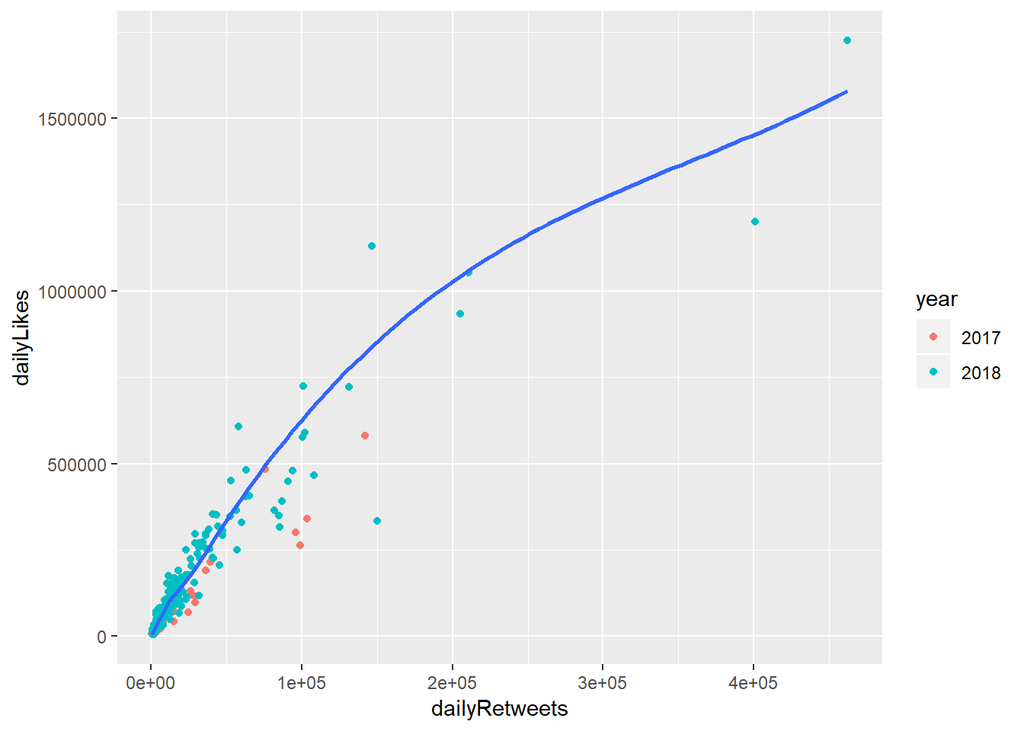

```r
(ret_likes <- daily_res %>%  ggplot(aes( dailyRetweets, dailyLikes ) ) + geom_point( aes(color = year),position = "jitter" ) + geom_smooth(se = FALSE) )
```

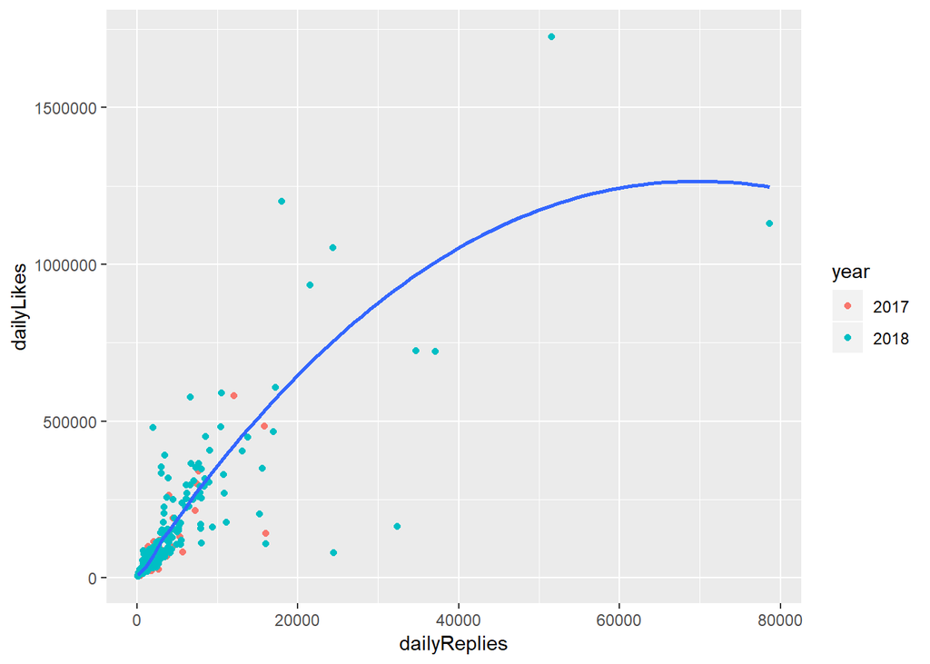

```r
(rep_likes <-  daily_res %>%  ggplot(aes( dailyReplies, dailyLikes ) ) + geom_point(aes(color = year),position = "jitter") + geom_smooth(se = FALSE) )
```

```r
#(g <- rbind(ret_likes, rep_likes, size="second"   ))
```

```r
cnbc_tsla <- read_csv("data/Twitter_Data/CNBC TSLA News since_2018-09-11 until_2018-11-11 - Twitter Search.csv")
#(cnbc_tsla <- cnbc_tsla %>%  distinct()  )

cnbc_tsla <- cnbc_tsla %>% filter(!duplicated(text) == TRUE)
problems(cnbc_tsla)
```

```
## # tibble [0 x 4]
## # ... with 4 variables: row <int>, col <int>, expected <chr>, actual <chr>
```

```r
(cnbc_by_date <- cnbc_tsla %>%  separate(time, into = c("year", "month", "day"), sep = "-" ) )
```

```
## # A tibble: 2,244 x 7
##    year  month day   text                           replies retweets likes
##    <chr> <chr> <chr> <chr>                            <int>    <int> <int>
##  1 2016  11    10    Tesla shares downshift into u~       4       10     8
##  2 2016  11    10    Cramer explains why investors~       3        8    12
##  3 2016  11    12    Elon Musk: Robots will take y~      30       55    56
##  4 2016  11    16    Tesla's ludicrously fast car ~       1        9    26
##  5 2016  11    16    How billionaire tech mogul El~       1       16    17
##  6 2016  11    17    BREAKING: Tesla's acquisition~       1       58    45
##  7 2016  11    17    Tesla and SolarCity sharehold~       0       10     7
##  8 2016  11    19    How billionaire tech mogul El~       3       12    19
##  9 2016  11    21    JUST IN: Tesla's acquisition ~       4       33    29
## 10 2016  11    21    Musk got what he wanted in Te~       0       10     6
## # ... with 2,234 more rows
```

```r
(cnbc_daily_res_table <- cnbc_by_date %>% group_by(year, month, day) %>% summarise(
  c_dailyLikes = sum(likes),
  c_dailyRep = sum(replies),
  c_dailyRet = sum(retweets)
  )  )
```

```
## # A tibble: 541 x 6
## # Groups:   year, month [?]
##    year  month day   c_dailyLikes c_dailyRep c_dailyRet
##    <chr> <chr> <chr>        <int>      <int>      <int>
##  1 2016  11    10              20          7         18
##  2 2016  11    12              56         30         55
##  3 2016  11    16              43          2         25
##  4 2016  11    17              52          1         68
##  5 2016  11    19              19          3         12
##  6 2016  11    21              35          4         43
##  7 2016  11    22              82          8         62
##  8 2016  11    28              13          1          6
##  9 2016  11    29              15          2         15
## 10 2016  12    01              17          5         17
## # ... with 531 more rows
```

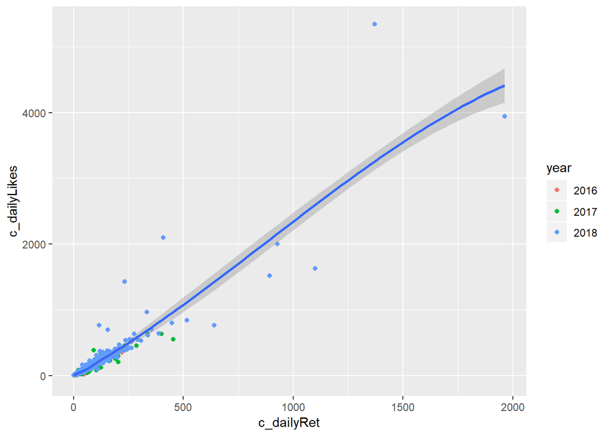

```r
(cnbc_ret_likes <- cnbc_daily_res_table %>%  ggplot(aes( c_dailyRet, c_dailyLikes ) ) + geom_point(aes(color = year), position = "jitter") + geom_smooth() )
```

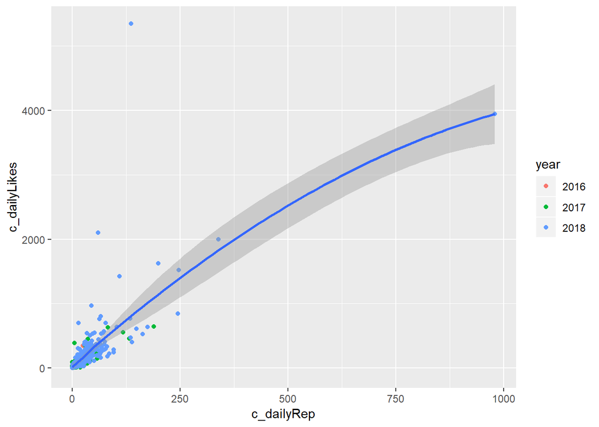

```r
(cnbc_rep_likes <-  cnbc_daily_res_table %>%  ggplot(aes( c_dailyRep, c_dailyLikes ) ) + geom_point(aes(color = year), position = "jitter") + geom_smooth() )
```

```r
tesla_elon <- read_csv("data/Twitter_Data/(_) @elonmusk @Tesla - Twitter Search.csv")
problems(tesla_elon)
```

```
## # tibble [0 x 4]
## # ... with 4 variables: row <int>, col <int>, expected <chr>, actual <chr>
```

```r
(by_date <- tesla_elon %>%  separate(time, into = c("year", "month", "day"), sep = "-" ) )
```

```
## # A tibble: 3,360 x 7
##    year  month day   text                           replies retweets likes
##    <chr> <chr> <chr> <chr>                            <int>    <int> <int>
##  1 2011  01    19    Listening to @elonmusk speak ~       0        0     0
##  2 2011  10    14    "@elonmusk\r\n@tesla\r\n#Dead~       0        0     0
##  3 2012  02    09    Thanks @tesla the #modelX is ~       0        0     0
##  4 2012  02    09    New @tesla #modelx looks amaz~       0        1     0
##  5 2012  04    16    more reasons u should b here ~       0        0     0
##  6 2012  05    22    Is @ElonMusk Tony Stark? @Tes~       0        0     0
##  7 2012  05    25    .@elonmusk @tesla & @spacex s~       0        0     0
##  8 2012  06    11    MT @SpaceX The man who's lead~       0        0     0
##  9 2012  06    21    This is so cool!  How they ma~       0        0     0
## 10 2012  06    28    Happy Birthday Mr. @elonmusk ~       0        0     0
## # ... with 3,350 more rows
```

```r
(daily_res <- by_date %>% group_by(year, month, day) %>% summarise(
  dailyLikes = sum(likes),
  dailyReplies = sum(replies),
  dailyRetweets = sum(retweets)
  )  )
```

```
## # A tibble: 468 x 6
## # Groups:   year, month [?]
##    year  month day   dailyLikes dailyReplies dailyRetweets
##    <chr> <chr> <chr>      <int>        <int>         <int>
##  1 2011  01    19             0            0             0
##  2 2011  10    14             0            0             0
##  3 2012  02    09             0            0             1
##  4 2012  04    16             0            0             0
##  5 2012  05    22             0            0             0
##  6 2012  05    25             0            0             0
##  7 2012  06    11             0            0             0
##  8 2012  06    21             0            0             0
##  9 2012  06    28             0            0             0
## 10 2012  07    06             0            0             0
## # ... with 458 more rows
```

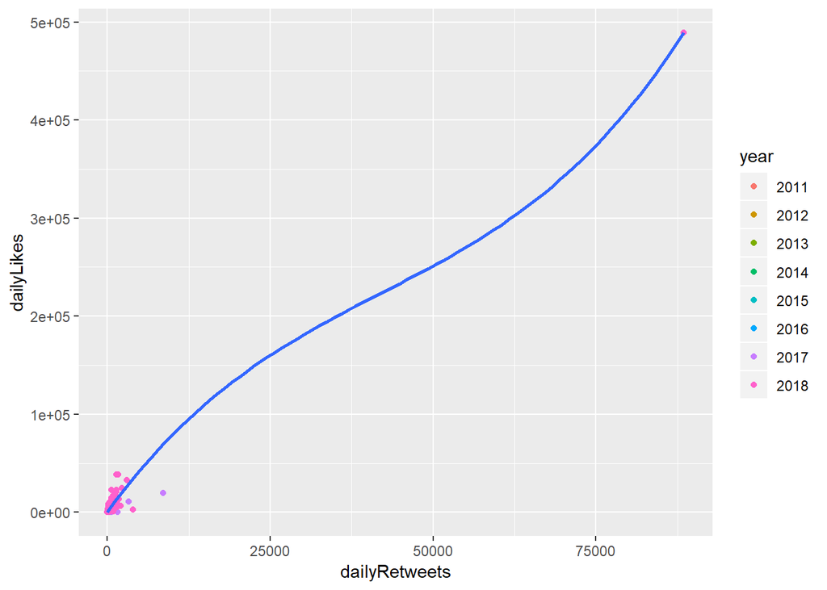

```r
(ret_likes <- daily_res %>%  ggplot(aes( dailyRetweets, dailyLikes ) ) + geom_point( aes(color = year ),position = "jitter" ) + geom_smooth(se = FALSE) )
```

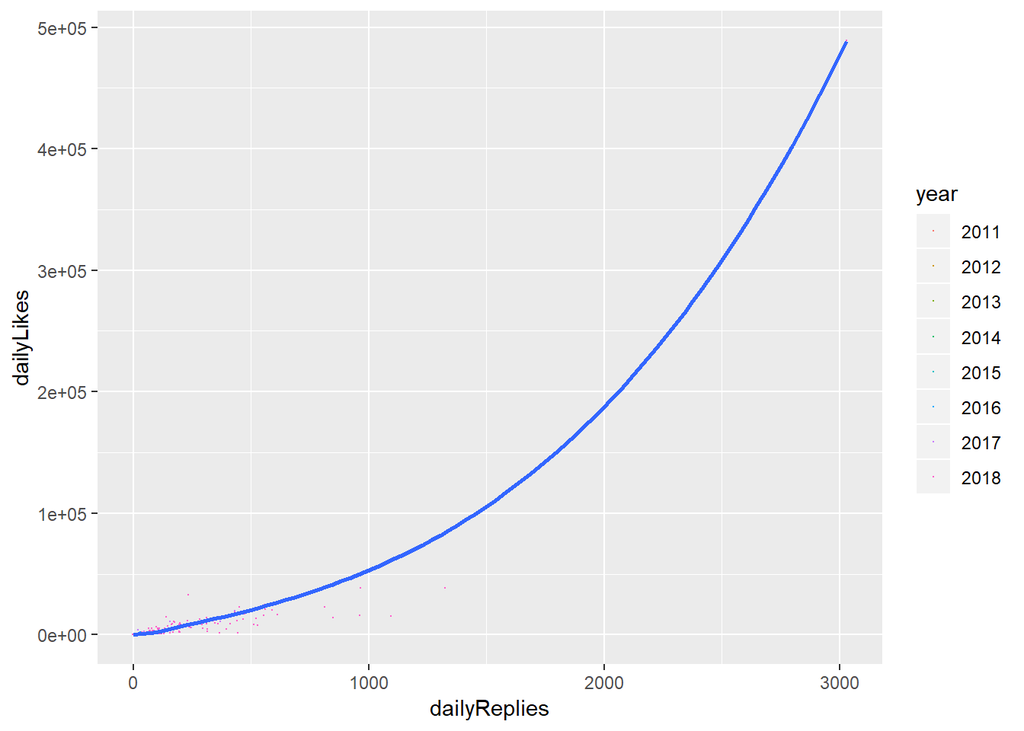

```r
(rep_likes <-  daily_res %>%  ggplot(aes( dailyReplies, dailyLikes ) ) + geom_point(aes(color = year), position = "jitter", size=I(0.1) ) + geom_smooth(se = FALSE) )
```

#Regression

##daily number regession

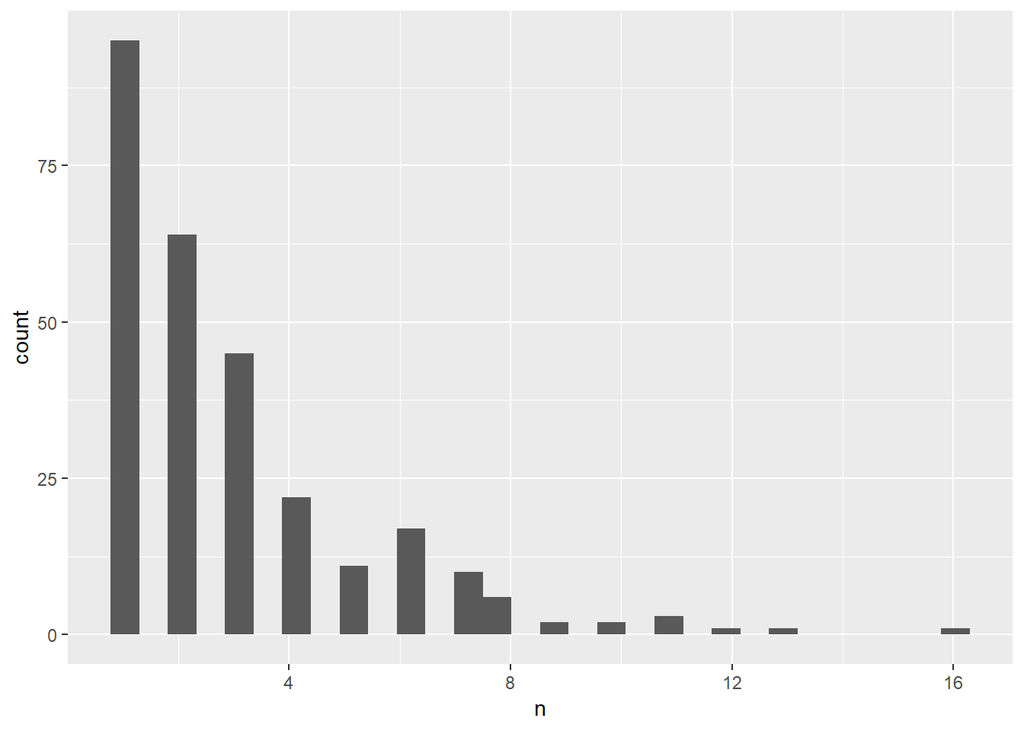

```r
daily_number<-elon_musk%>%mutate(Date=as.character.Date(time))%>%group_by(Date)%>%count()
ggplot(daily_number)+geom_histogram(aes(n))
```

```r
daily_number_price<-daily_number%>%left_join(daily_price,by=c("Date"))

mod_num1<-lm(log(Close)~n,data=daily_number_price)
coef1<-coef(mod_num1)
summary(mod_num1)
```

```
##
## Call:
## lm(formula = log(Close) ~ n, data = daily_number_price)
##
## Residuals:
##      Min       1Q   Median       3Q      Max
## -0.22290 -0.06323  0.00715  0.07811  0.19183
##
## Coefficients:
##               Estimate Std. Error t value Pr(>|t|)
## (Intercept)  5.7514908  0.0101514 566.571   <2e-16 ***
## n           -0.0006115  0.0026716  -0.229    0.819
## ---
## Signif. codes:  0 '***' 0.001 '**' 0.01 '*' 0.05 '.' 0.1 ' ' 1
##
## Residual standard error: 0.09093 on 199 degrees of freedom
##   (79 observations deleted due to missingness)
## Multiple R-squared:  0.0002632,  Adjusted R-squared:  -0.004761
## F-statistic: 0.05238 on 1 and 199 DF,  p-value: 0.8192
```

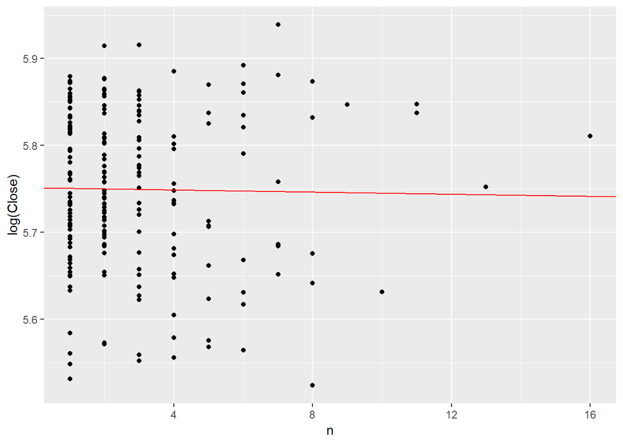

```r
ggplot(daily_number_price,aes(x=n,y=log(Close)))+geom_point()+
  geom_abline(intercept = coef1[1],slope = coef1[2],color="red")
```

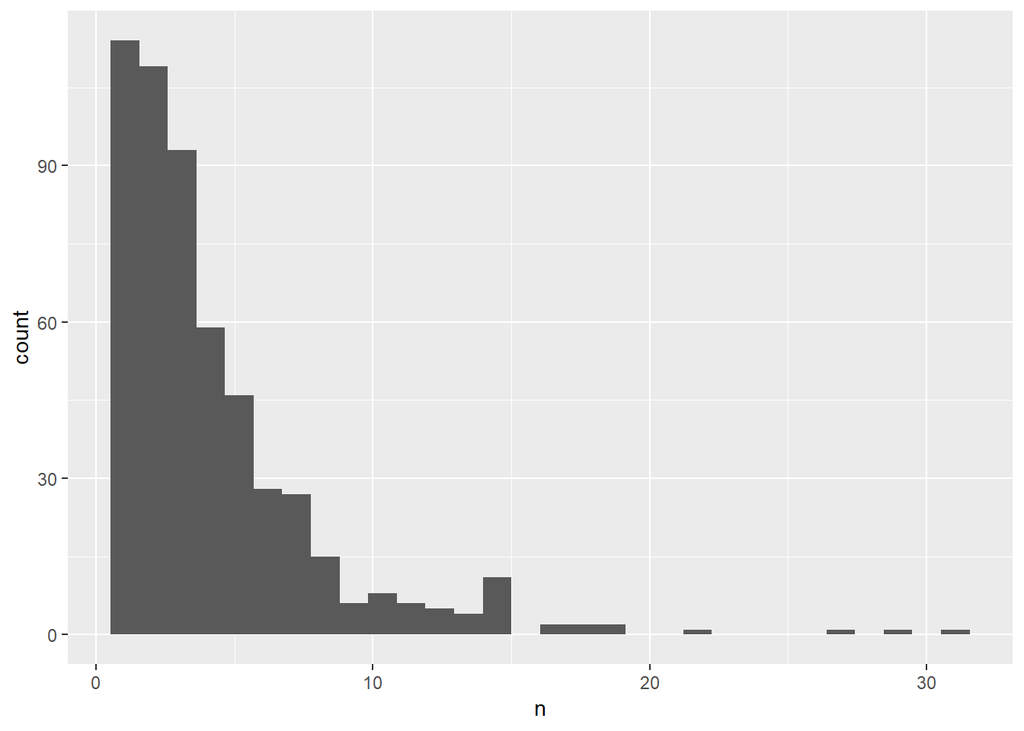

```r
cnbc_tsla<-cnbc_tsla%>%filter(!(duplicated(text)==TRUE))
daily_number_cnbc<-cnbc_tsla%>%mutate(Date=as.character.Date(time))%>%group_by(Date)%>%count()
ggplot(daily_number_cnbc)+geom_histogram(aes(n))
```

```r
daily_number_price_cnbc<-daily_number_cnbc%>%left_join(daily_price,by=c("Date"))

mod_num2<-lm(log(Close)~n,data=daily_number_price_cnbc)
coef2<-coef(mod_num2)
summary(mod_num2)
```

```
##
## Call:
## lm(formula = log(Close) ~ n, data = daily_number_price_cnbc)
##
## Residuals:
##      Min       1Q   Median       3Q      Max
## -0.51254 -0.06600  0.02346  0.10664  0.23487
##
## Coefficients:
##             Estimate Std. Error t value Pr(>|t|)
## (Intercept) 5.713405   0.010263 556.712   <2e-16 ***
## n           0.002485   0.001664   1.493    0.136
## ---
## Signif. codes:  0 '***' 0.001 '**' 0.01 '*' 0.05 '.' 0.1 ' ' 1
##
## Residual standard error: 0.1448 on 436 degrees of freedom
##   (103 observations deleted due to missingness)
## Multiple R-squared:  0.00509,    Adjusted R-squared:  0.002808
## F-statistic:  2.23 on 1 and 436 DF,  p-value: 0.136
```

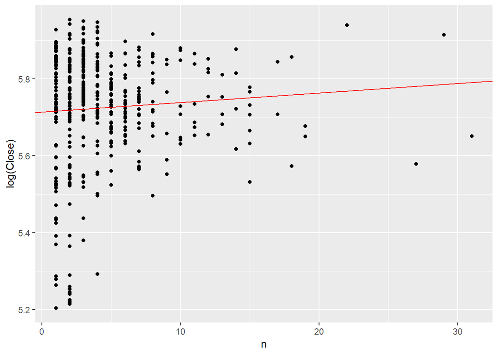

```r
ggplot(daily_number_price_cnbc,aes(x=n,y=log(Close)))+geom_point()+
  geom_abline(intercept = coef2[1],slope = coef2[2],color="red")
```

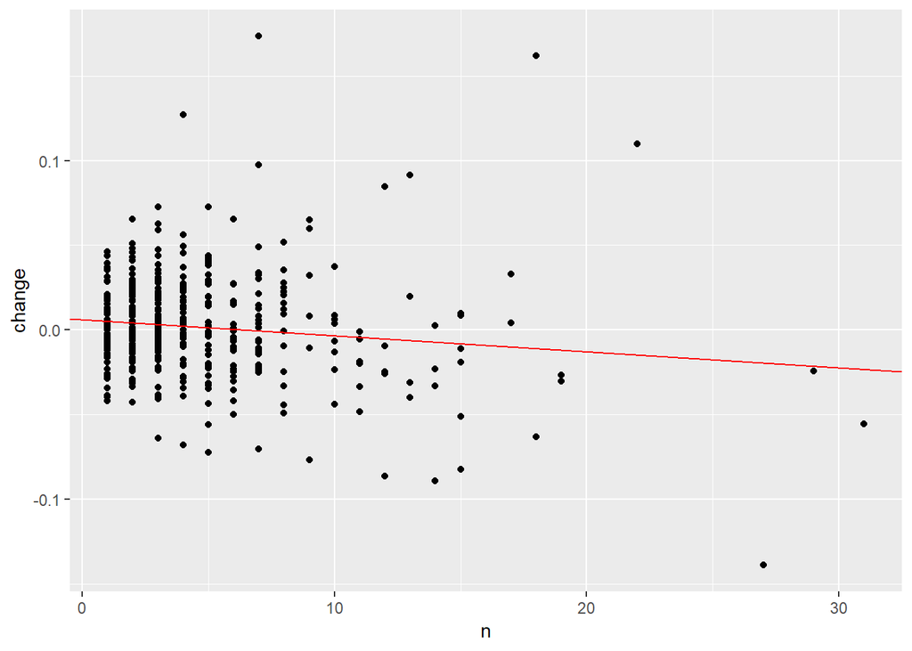

```r
price_lag<-daily_price%>%mutate(change=(Close/lag(Close,1)-1))
lag<-daily_number_price_cnbc%>%left_join(price_lag,by=c("Date"))
mod_num3<-lm(change~n,data=lag)
coef3<-coef(mod_num3)
ggplot(lag,aes(x=n,y=change))+geom_point()+
  geom_abline(intercept = coef3[1],slope = coef3[2],color="red")
```

We found out that there are several days when the number of twitter about Tesla was extremely high. So, we filtered these outliers to see what happened on these dates.

```r
daily_number_price_cnbc%>%arrange(desc(n))
```

```
## # A tibble: 541 x 5
## # Groups:   Date [541]
##    Date           n  Open Close   Volume
##    <chr>      <int> <dbl> <dbl>    <int>
##  1 2018-05-03    31  279.  284. 17352100
##  2 2018-08-08    29  369.  370. 24571200
##  3 2018-09-28    27  270.  265. 33649700
##  4 2018-08-07    22  344.  380. 30875800
##  5 2018-05-14    19  303.  292.  7286800
##  6 2018-05-15    19  285.  284.  9519200
##  7 2018-08-02    18  328.  350. 23215000
##  8 2018-09-07    18  260.  263. 22491900
##  9 2018-02-07    17  339.  345   6969200
## 10 2018-05-02    17  299.  301.  8970400
## # ... with 531 more rows
```

```r
cnbc_tsla%>%filter(time=="2018-05-03")
```

```
## # A tibble: 31 x 5
##    time       text                                  replies retweets likes
##    <date>     <chr>                                   <int>    <int> <int>
##  1 2018-05-03 Even in 2006, after his first rocket~       2       12    42
##  2 2018-05-03 Ex-Google exec: 3 traits that make E~       1       10     8
##  3 2018-05-03 Sacconaghi on Musk earnings call: 'T~       6       26    55
##  4 2018-05-03 Tesla's Elon Musk: Uber-Airbnb-type ~       6       21    37
##  5 2018-05-03 Every CEO would love to go off like ~       7        9    30
##  6 2018-05-03 After Tesla's tense earnings call, h~       4        9    12
##  7 2018-05-03 Tesla bull sounds off after conferen~       1        2     5
##  8 2018-05-03 "Tesla's bizarre earnings call is th~       5        4    11
##  9 2018-05-03 Everyone's talking about Elon Musk's~       4        8    17
## 10 2018-05-03 Cramer defends Elon Musk's crazy cal~       3        7    17
## # ... with 21 more rows
```

```r
cnbc_tsla%>%filter(time=="2018-08-08")
```

```
## # A tibble: 29 x 5
##    time       text                                  replies retweets likes
##    <date>     <chr>                                   <int>    <int> <int>
##  1 2018-08-08 "\"This is out there, even for Tesla~       4       14    19
##  2 2018-08-08 Elon Musk's Tesla stock boost may lo~       5       10    11
##  3 2018-08-08 "\"People love Elon Musk because he'~      17       36    78
##  4 2018-08-08 "The \"Squawk on the Street\" news c~       1        8    17
##  5 2018-08-08 Tesla likely to face SEC investigati~       9       27    35
##  6 2018-08-08 Musk says Tesla's new A.I. chip is p~       6       13    30
##  7 2018-08-08 It's been 24 hours and Tesla still h~       7        7    14
##  8 2018-08-08 Cramer's 4 reasons for why Tesla's s~       2        3    11
##  9 2018-08-08 If Elon Musk actually doesn't have t~      10       15    32
## 10 2018-08-08 Musk tweet sparks debate on Tesla le~       0       13    17
## # ... with 19 more rows
```

##multivariate regression

Then, we gave sentiment scores to each twitter text and regress them on the price change.

###sentiment scores

```r
library(syuzhet)
library(SnowballC)
library(NLP)
```

```r
library(tm)
library(wordcloud)
name <- "Elon Musk (@elonmusk) _ Twitter"
name <- "CNBC TSLA News since_2018-09-11 until_2018-11-11 - Twitter Search"
name <- "(_) @elonmusk @Tesla - Twitter Search"
import_path <- paste("data/Twitter_Data/", name, ".csv", sep='')
tweets <- read_csv(import_path) %>%
  mutate(text = str_to_lower(text)) %>%
  mutate(text = str_replace_all(text, "https?.*\\s?","")) %>%
  mutate(text = str_replace_all(text, "[#@].*\\s?","")) %>%
  mutate(text = str_replace_all(text, "pic.twitter.*\\s?","")) %>%
  mutate(text = str_replace_all(text, "rt","")) %>%
  mutate(text = str_replace_all(text, "[[:punct:]]","")) %>%
  mutate(text = str_replace_all(text, "[ |\t]{2,}","")) %>%
  mutate(text = str_replace_all(text, "^\\s","")) %>% # Remove blank spaces at the beginning
  mutate(text = str_replace_all(text, "\\s$", "")) %>% #Remove blank spaces at the end
  mutate(text = removeWords(text,stopwords()))
sentiment_scores <- get_nrc_sentiment(tweets$text)

tweets_with_scores <- merge(tweets, sentiment_scores, by="row.names", all.x=TRUE) %>%
  select(-1)

export_path <- paste("data/Twitter_Data/", name, "_with_scores.csv", sep='')
write.table(tweets_with_scores, file = export_path, sep=",", row.names=FALSE)
# all_words <- paste(tweets$text, collapse=', ' )
#
# wordcloud(all_words,min.freq = 1,colors=brewer.pal(8, "Dark2"),random.color = TRUE,max.words = 500)
# word.df <- as.vector(tweets.df2)
#
# emotion.df <- get_nrc_sentiment(word.df)
#
# emotion.df2 <- cbind(tweets.df2, emotion.df)
#
# head(emotion.df2)
```

```r
cnbc_score<-read_csv("data/TWitter_Data/CNBC TSLA News since_2018-09-11 until_2018-11-11 - Twitter Search_with_scores.csv")
```

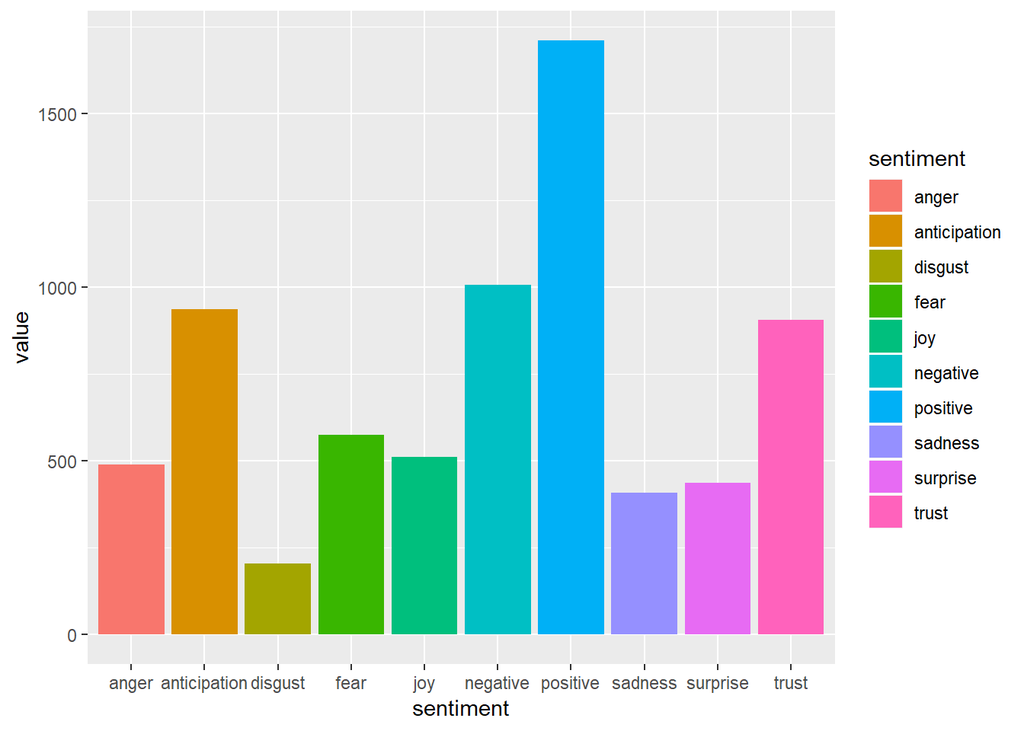

```r
sentiment_cnbc<-list(x=c("anger","anticipation","disgust","fear","joy","sadness","surprise","trust","negative","positive"),y=cnbc_score%>%
  select(anger,anticipation,disgust,fear,joy,sadness,surprise,trust,negative,positive)%>%
  colSums())
sentiment_cnbc<-as_tibble(sentiment_cnbc)
colnames(sentiment_cnbc)<-c("sentiment","value")

ggplot(sentiment_cnbc)+geom_col(aes(sentiment,value,fill=sentiment))
```

###multivariate regression

```r
price_lag <- daily_price %>%
  mutate(log_close = log(Close)) %>%
  mutate(change=(Close/lag(Close,1)-1))

tweets_with_scores <- tweets_with_scores %>%
  mutate(Date=as.Date(time, format = "%d.%m.%Y")) %>%
  select(Date, everything()) %>%
  select(-time)

emotions <- colnames(tweets_with_scores)[6:15] %>%
  paste(shQuote(., type="sh"), collapse=", ")

summarized_tweets_with_scores <- tweets_with_scores %>%
  group_by(Date) %>%
  summarize(
    anger = sum(anger),
    anticipation = sum(anticipation),
    disgust = sum(disgust),
    fear = sum(fear),
    joy = sum(joy),
    sadness = sum(sadness),
    surprise = sum(surprise),
    trust = sum(trust),
    negative = sum(negative),
    positive = sum(positive)
  )
  # colSums(tweets_with_scores[, c("anger", "anticipation", "disgust", "fear", "joy", "sadness", "surprise", "trust", "negative", "positive")], na.rm=TRUE)

# for (i in colnames(tweets_with_scores)[6:15]) {
#   col_name = paste(i, "sum", sep='_')
#   print(col_name)
#   tweets_with_scores <- tweets_with_scores %>%
#     group_by(date)%>%
#     mutate(!!col_name := sum(i)) %>%
#     group_by(date)
# }

daily_price_with_scores <- price_lag %>%
  mutate(Date=as.Date(Date)) %>%
  left_join(summarized_tweets_with_scores, by="Date") %>%
  .[complete.cases(.), ]

(mod_num2<-lm(change~anger+anticipation+disgust+fear+joy+sadness+surprise+trust+negative+positive,data=daily_price_with_scores))
```

```
##
## Call:
## lm(formula = change ~ anger + anticipation + disgust + fear +
##     joy + sadness + surprise + trust + negative + positive, data = daily_price_with_scores)
##
## Coefficients:
##  (Intercept)         anger  anticipation       disgust          fear
##    0.0006293    -0.0033032     0.0002444    -0.0031930     0.0037343
##          joy       sadness      surprise         trust      negative
##   -0.0006283    -0.0019178    -0.0008255    -0.0005737     0.0014779
##     positive
##    0.0004752
```

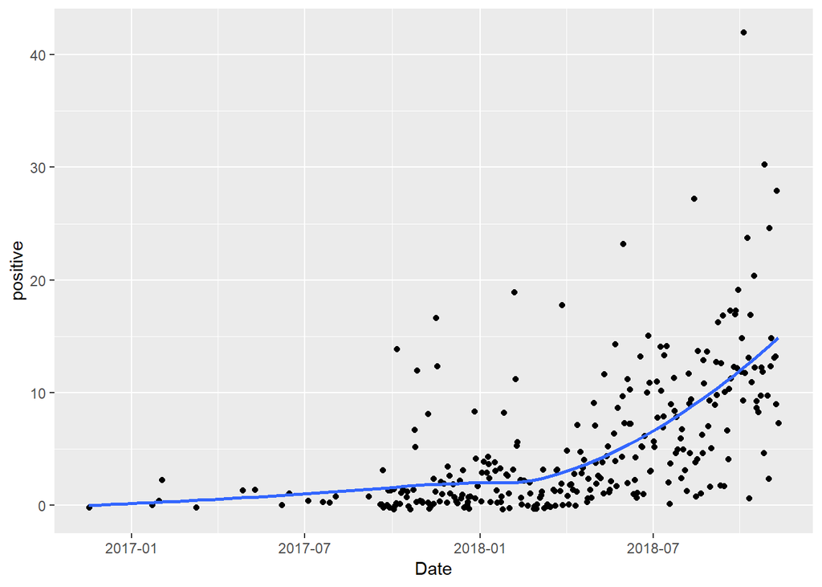

```r
(daily_price_with_scores %>%
    ggplot(aes( Date, positive ) ) +
    geom_point(position = "jitter" ) +
    geom_smooth(se = FALSE))
```

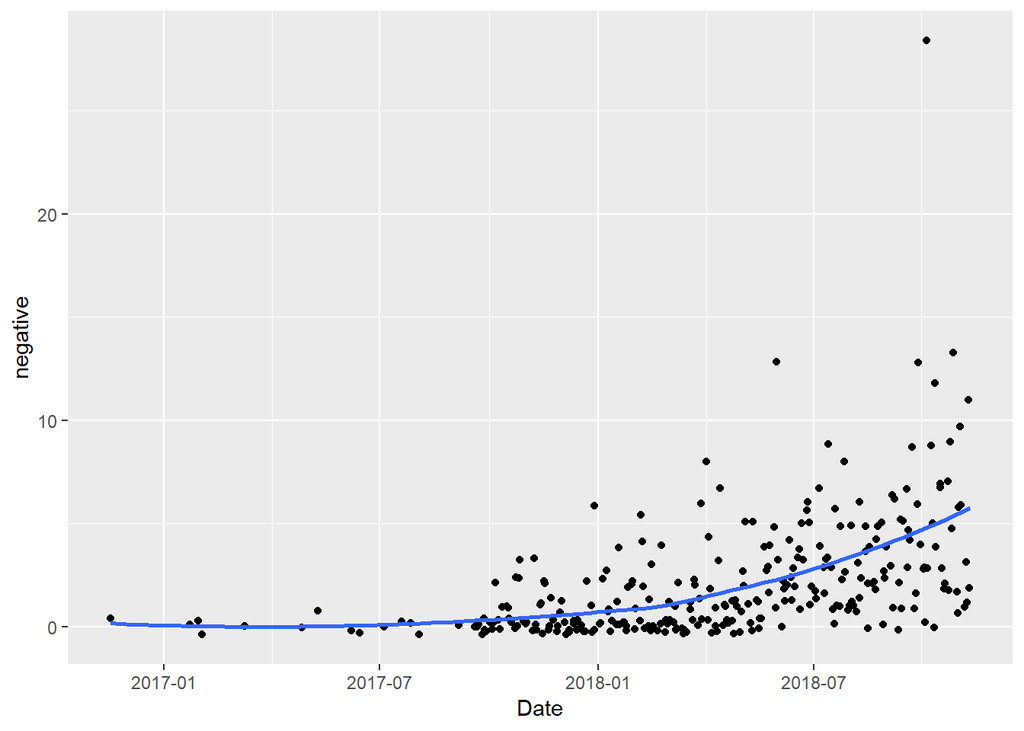

```r
(daily_price_with_scores %>%
    ggplot(aes( Date, negative) ) +
    geom_point(position = "jitter" ) +
    geom_smooth(se = FALSE))
```

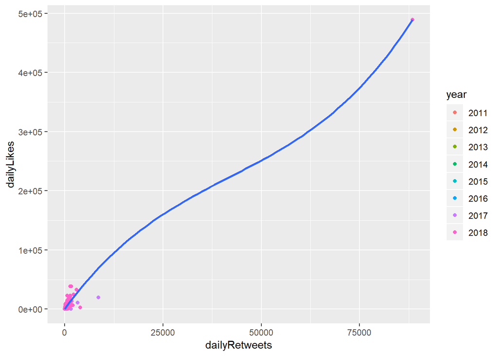

```r
(ret_likes <- daily_res %>%  ggplot(aes( dailyRetweets, dailyLikes ) ) + geom_point( aes(color = year ),position = "jitter" ) + geom_smooth(se = FALSE))
```